# Lab 07 Regression

## RE 519 Data Analytics and Visualization | Autumn 2025

- Lab 07-A: Regression in Statistics
  - A Simple Linear Regression
  - Check Assumptions
  - Adjustment to the Regression
  - Interactions and Non-linear Variables
  - Compare Models
  - Prediction
  - 📚 TODO: Explain the Results of Logistic Regression
- Lab 07-B: Regression in Machine Learning
  - Data Preparation
  - Model Specification
  - Tuning Grid for Penalty
  - Cross-validation Setup
  - Model Training via Grid Search
  - Cross-validation Results
  - Fit the Final Model using the Best $\lambda$
  - 📚 TODO: Review the Code for Regression
  - 📚 TODO: Machine Learning to Predict the Rental Value
- Acknowledgement

In Lab 7, we will go back to the **King County sales** data from maintained by [Andy Krause](https://www.andykrause.com/index.html) at Zillow. You can find the datasets and Readme file in [this repository](https://github.com/andykrause/kingCoData).

In Part A, we will use classical regression, which considers more on the model specification, assumptions, and parameter interpretation. In Part B, we will still use regression but under the context of machine learning. We care about the prediction accuracy on unseen test dataset. A seminal paper discusses the **two cultures in statistical modeling**: [Statistical Modeling: The Two Cultures. Leo Breiman. 2001.](https://projecteuclid.org/journals/statistical-science/volume-16/issue-3/Statistical-Modeling--The-Two-Cultures-with-comments-and-a/10.1214/ss/1009213726.full)

The due day for each lab can be found on the [course wesbite](https://www.yuehaoyu.com/data-analytics-visualization/). The submission should include Rmd, html, and any other files required to rerun the codes.

From Lab 4, the use of any generative AI tool (ChatGPT, Copilot, etc.) is **allowed** for coding assignments. But, I still encourage you to write codes by yourself and use AI tools as a way to debug and explore new knowledge. More information about [Academic Integrity](https://www.yuehaoyu.com/data-analytics-visualization/syllabus/#academic-integrity) and [the Use of AI](https://www.yuehaoyu.com/data-analytics-visualization/syllabus/#use-of-ai).

## Lab 07-A: Regression in Statistics

```r
#install.packages("modelsummary") # you only need to run the installation once
#install.packages("devtools") # if you are using a Windows computer
#devtools::install_github('andykrause/kingCoData') # you only need to run the installation once
library('tidyverse')
library(modelsummary) # the package for formatting the regression result table
library('kingCoData') # load the data package
```

```r
data(kingco_sales) # load the sale data
# only select the sales in 2023
sales <- kingco_sales %>%
  filter(sale_date >= as.Date("2023-01-01") & sale_date <= as.Date("2023-12-31"))
```

### A Simple Linear Regression

#### Checking Correlation

Correlation ($r$) measures the strength and direction of a linear relationship between two variables. The most common one for continuous numeric data is [**Pearson correlation**](https://en.wikipedia.org/wiki/Pearson_correlation_coefficient), which ranges from -1 to 1.

- +1 Perfect positive correlation
- 0 No linear relationship
- –1 Perfect negative correlation

```r
cor(sales[, c("sale_price", "sqft", "year_built", "condition")])
```

```
##             sale_price        sqft   year_built   condition
## sale_price 1.000000000  0.53952741  0.009373296  0.01784696
## sqft       0.539527410  1.00000000  0.297844019 -0.05792704
## year_built 0.009373296  0.29784402  1.000000000 -0.35992275
## condition  0.017846960 -0.05792704 -0.359922752  1.00000000
```

#### Scatterplots

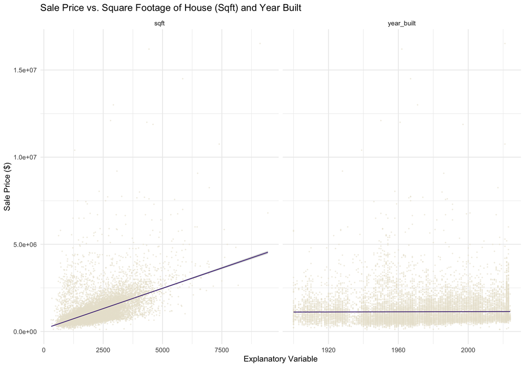

```r
sales_long <- sales |>
  pivot_longer(
    cols = c(sqft, year_built),
    names_to = "variable",
    values_to = "xvalue"
  )

ggplot(sales_long, aes(x = xvalue, y = sale_price)) +
  geom_point(size = 0.3, alpha = 0.5, color = "#e8e3d3") +
  geom_smooth(linewidth = 0.5, method = "lm", formula = "y~x", color = "#4b2e83") +
  facet_wrap(~ variable, scales = "free_x") +
  labs(
    x = "Explanatory Variable",
    y = "Sale Price ($)",
    title = "Sale Price vs. Square Footage of House (Sqft) and Year Built"
  ) +
  theme_minimal()
```

#### Fitting the Model

Starting to fit a regression, you define a family of models that express a precise, but generic, pattern that you want to capture. For example, the pattern might be a straight line, or a quadratic curve. You will express the model family as an equation like $y = \beta_0 + \beta_1 x$ or $y = \beta_0 + \beta_1 x^2$. Here, $x$ and $y$ are known variables from your data, and $\beta_0$ and $\beta_1$ are parameters that can vary to capture different patterns.

```r
# lm means linear model
# we don't need to add intercept, R will add it for us
simple_lm <- lm(data = sales, sale_price ~ sqft + year_built)
```

We can check the results using `summary()` (result table) and `confint()` (confidence intervals).

```r
summary(simple_lm)
```

```
##
## Call:
## lm(formula = sale_price ~ sqft + year_built, data = sales)
##
## Residuals:
##      Min       1Q   Median       3Q      Max
## -1877471  -322074   -92840   173424 13832047
##
## Coefficients:
##               Estimate Std. Error t value Pr(>|t|)
## (Intercept)  7.982e+06  3.268e+05   24.42   <2e-16 ***
## sqft         5.082e+02  5.975e+00   85.06   <2e-16 ***
## year_built  -4.009e+03  1.672e+02  -23.98   <2e-16 ***
## ---
## Signif. codes:  0 '***' 0.001 '**' 0.01 '*' 0.05 '.' 0.1 ' ' 1
##
## Residual standard error: 653700 on 15651 degrees of freedom
## Multiple R-squared:  0.3162, Adjusted R-squared:  0.3161
## F-statistic:  3619 on 2 and 15651 DF,  p-value: < 2.2e-16
```

```r
confint(simple_lm)
```

```
##                    2.5 %       97.5 %
## (Intercept) 7341424.5882 8622695.8739
## sqft            496.5235     519.9459
## year_built    -4336.6278   -3681.2999
```

How to read the tables?

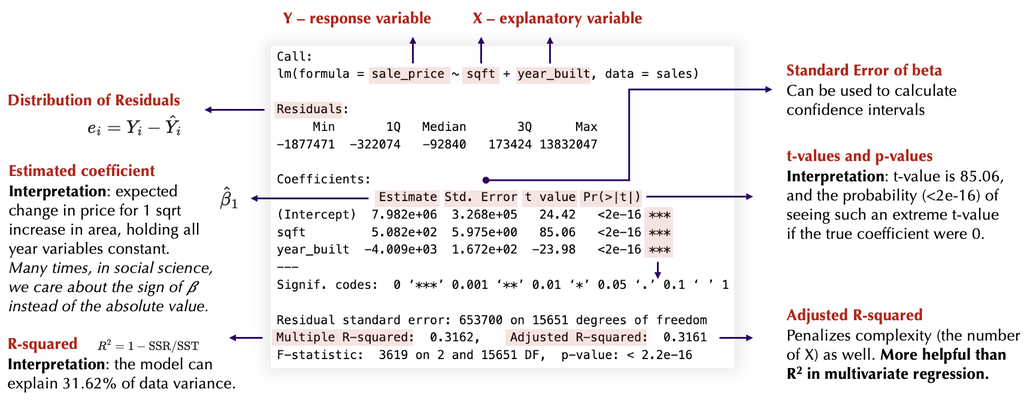

Results from R and Interpretations

**Click to view additional notes on reading the results**

**Hypothesis**: The model test if $Y$ is associated with $X$. The null hypothesis $H_0$ is that there is no linear relationship between the response variable and the explanatory variable(s), and the alternative hypothesis $H_1$ is that there is relationship.

**Estimate and standard error**:In the model, estimate is the estimation of coefficient $\beta$, std.error is the standard error for estimation. The standard error of the coefficient is an estimate of the standard deviation of the coefficient $\beta$. In effect, it is telling us how much uncertainty there is with our coefficient. The standard error is often used to create confidence intervals.

**t-statistic**: The t-statistic is simply the coefficient divided by the standard error. In general, we want our coefficients to have large t-statistics, because it indicates that our standard error is small in comparison to our coefficient. Simply put, we are saying that the coefficient is $t$ standard errors away from zero.

**p-value**: If you see the variable has p value $\leq 0.05$, or you can also see the star next to $Pr(>|t|))$, we can say we reject the null hypothesis. In practice, any p-value below 0.05 is usually deemed as significant. What do we mean when we say significant? It means we are confident that the coefficient is not zero, meaning the coefficient does in fact add value to the model by helping to explain the variance within our dependent variable. **Note:** reading the stars this way only works for individual variables and not categorical variables.

**R-squared**: R-squared explains how much variation of y can be explained by the model. This is helpful for univariate regression, but starts to become fairly unhelpful for multivariate regression. We would look at adjusted R-squared, which penalizes complexity.

### Check Assumptions

For a normal linear model to be a good model, there are some conditions/assumptions that need to be fulfilled.

- **Linearity**: $Y$ changes linearly with $X$. $Y$ can be described by a linear combination of $X$ (or transformation of $X$).
- **Independence**: the residuals are independent of each other. We are using time series and spatial data so we are likely violate this assumption.
- **Normality and homoscedasticity for error terms**: the distribution of the residuals is normal with equal variance.
- **No perfect multicollinearity among X**: X should not be a linear combination of each other. Example: using all three scores as $X$ if total score = part A score + part B score.

If these assumptions are not met, the inference with the computed standard error is invalid. That is, if the assumptions are not met, the standard error should not be trusted, or should be computed using alternative methods.

The quickest way to check many assumptions is to use `plot(model)` and it will generated several key plots for us. We use `which` to specify the plot but in practice, you can generate them at the same time.

We will setup a ‘perfect’ model as the example to compare:

```r
example_x <- seq(1, 100, by = 1)
example_y <- 3 + 2 * example_x + rnorm(100, mean = 0, sd = 2)
example_model <- lm(example_y ~ example_x)
```

#### Residuals vs Fitted

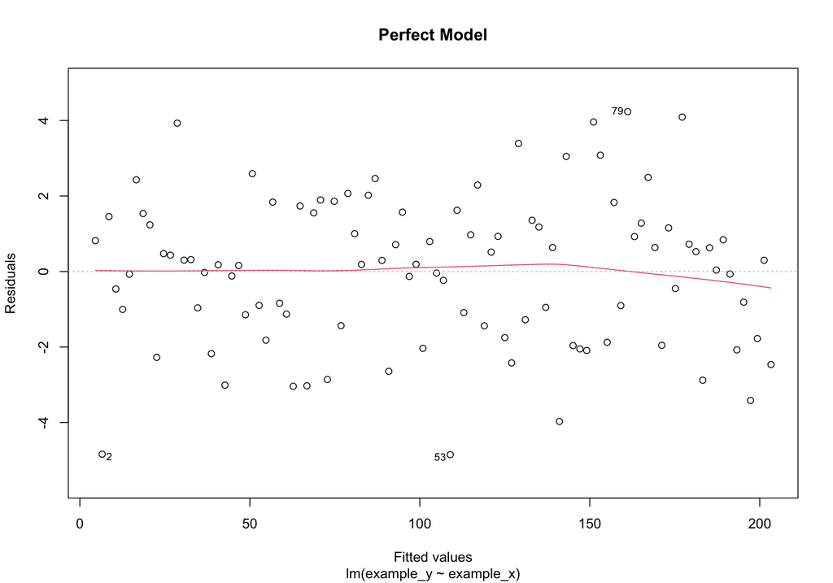

```r
plot(example_model, which = 1, title("Perfect Model"))
```

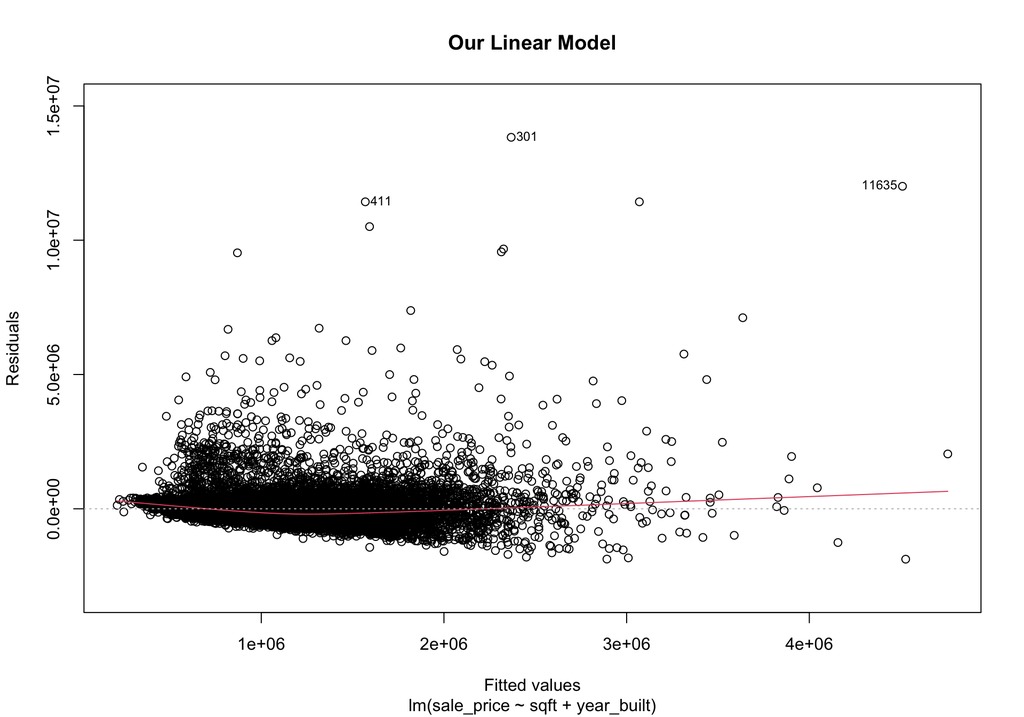

```r
plot(simple_lm, which = 1, title("Our Linear Model"))
```

**Horizontal Axis**: Fitted values (predicted values) from the regression model.

**Vertical Axis**: Residuals (the differences between the observed values and the predicted values).

**Interpretation**: This plot helps you check for linearity and homoscedasticity (equal variance of error terms). Ideally, you should see a horizontal red line (for linearity) and random scatter of points with no discernible pattern (for homoscedasticity). If there’s a pattern (e.g., a curve or fan shape), it suggests non-linearity or heteroscedasticity, which might indicate a problem with the model.

**In our case**: no much concern on the linearity (red line is around 0); some level of heteroscedasticity (fan shape - residuals variance increase with the increase of fitted values). That happens a lots in price data, which is often right-skewed/long-tailed and log transformation to $Y$ is a common strategy.

#### Q–Q Plot

[Q-Q plots](https://library.virginia.edu/data/articles/understanding-q-q-plots) helps us to compare a set of data with normal distribution. If the data is perfectly normally distributed, it should follow the dash line. In our case, we can see the residuals are not normally distributed. It reconfirms the price data is right-skewed/long-tailed.

- S-shaped curve: heavier tails or more peaked than the normal distribution (for example, a t-distribution).
- Curved upward or downward: skewness (the data are not symmetric).
- Clearly deviating from the straight line: Suggests the data are not normally distributed.

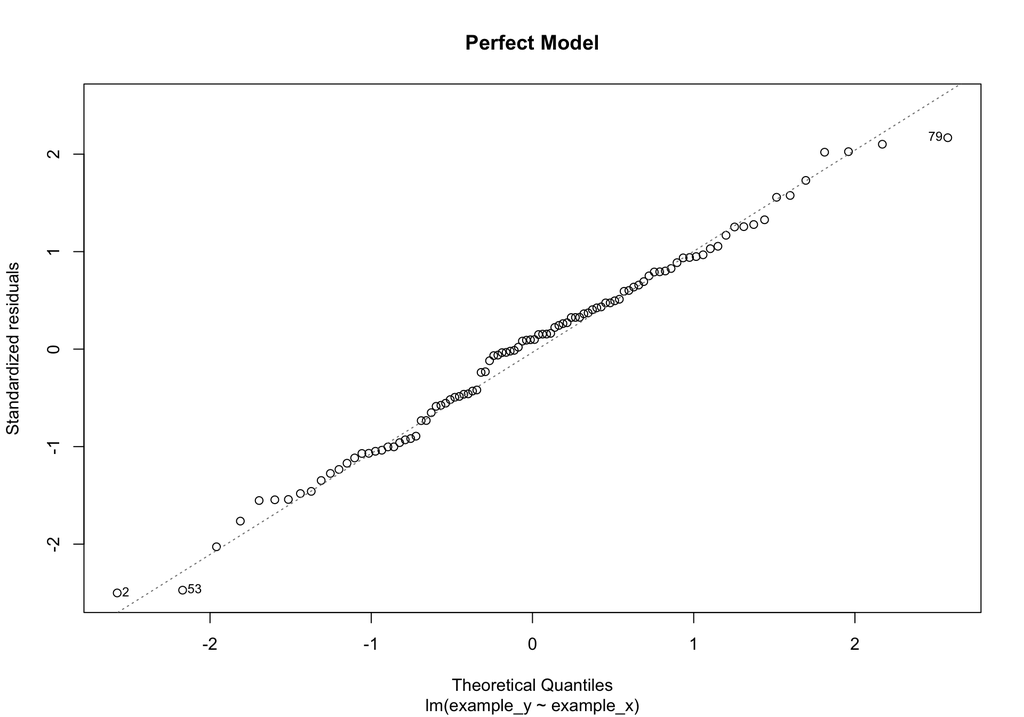

```r
plot(example_model, which = 2, title("Perfect Model"))
```

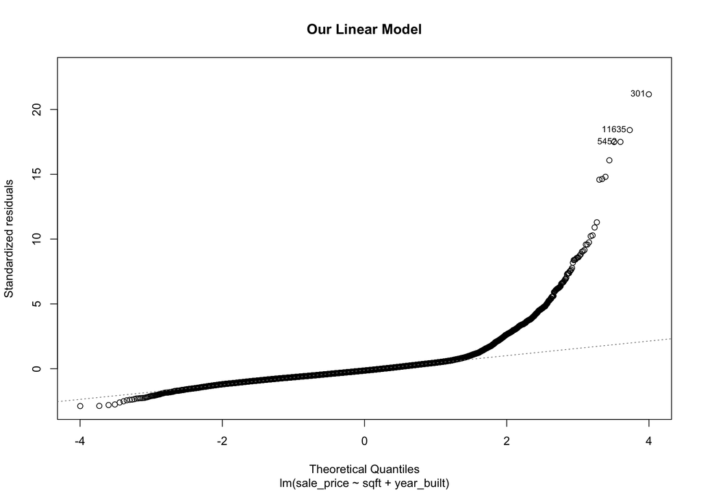

```r
plot(simple_lm, which = 2, title("Our Linear Model"))
```

#### Residuals vs Leverage

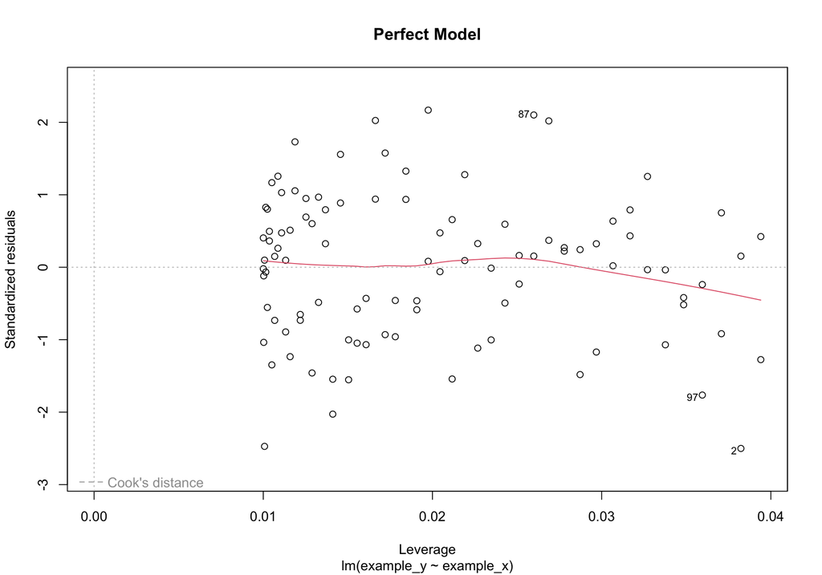

```r
plot(example_model, which = 5, title("Perfect Model"))
```

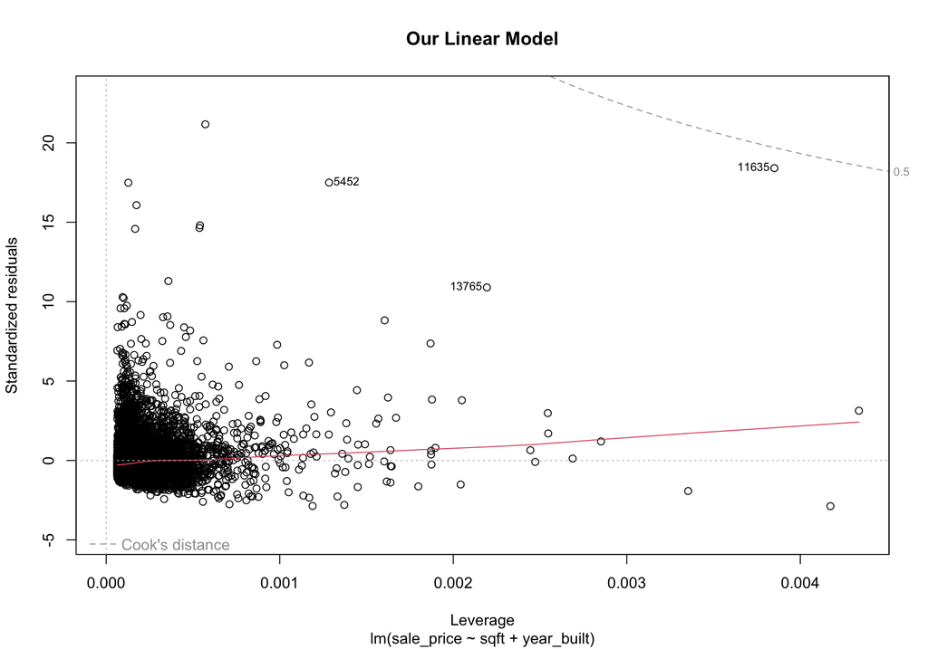

```r
plot(simple_lm, which = 5, title("Our Linear Model"))
```

**Horizontal Axis**: Leverage values, which indicate how much the corresponding observation influences the fit.

**Vertical Axis**: Standardized residuals (residuals divided by their standard deviation).

**Interpretation**: This plot helps you identify *influential data points (outliers)* and *influential cases (observations with high leverage)*. Points that are far from the horizontal line at zero indicate observations with high standardized residuals. Points that are far from the vertical line at 1/n (where n is the number of observations) have high leverage. The gray dash line is the Cook’s Distance; points above the line have will have noticeable change to regression line if removed.

**In our case**: There are a few outliers (5452, 13765, 11635) but it is not a super serious problem (within Cook’s distance = 0.5). We can check whether the original data is correctly collected. After that, we can decide whether to remove them.

#### Multicollinearity

The Variance Inflation Factor (VIF) measures how much the variance of a regression coefficient is inflated due to collinearity with other predictors. If there is perfect multicollinearity, R will automatically drop one of the variables. If there is imperfect multicollinearity. R won’t drop and the model estimates will be biased.

- VIF = 1: no correlation with other predictors.
- VIF > 5: moderate multicollinearity concern, potential for removal.
- VIF > 10: serious multicollinearity, must remove the variable

```r
#install.packages('car')
library(car)
vif(simple_lm)
```

```
##       sqft year_built
##   1.097347   1.097347
```

### Adjustment to the Regression

Because the original model showed heteroscedasticity (the “fan shape” pattern in residual plots), we apply a log transformation to the $Y$ `sale_price`. Almost everything is better after the transformation.

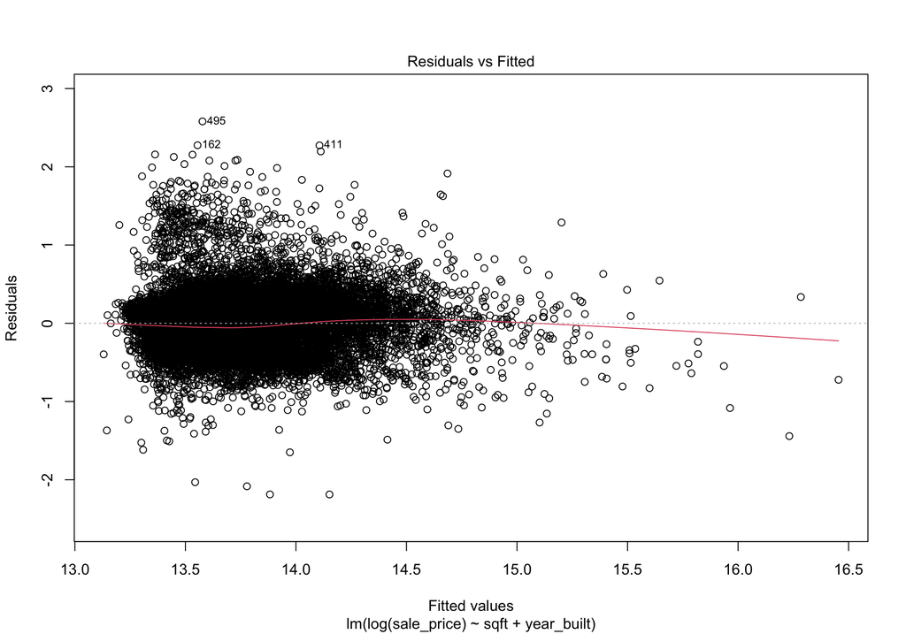

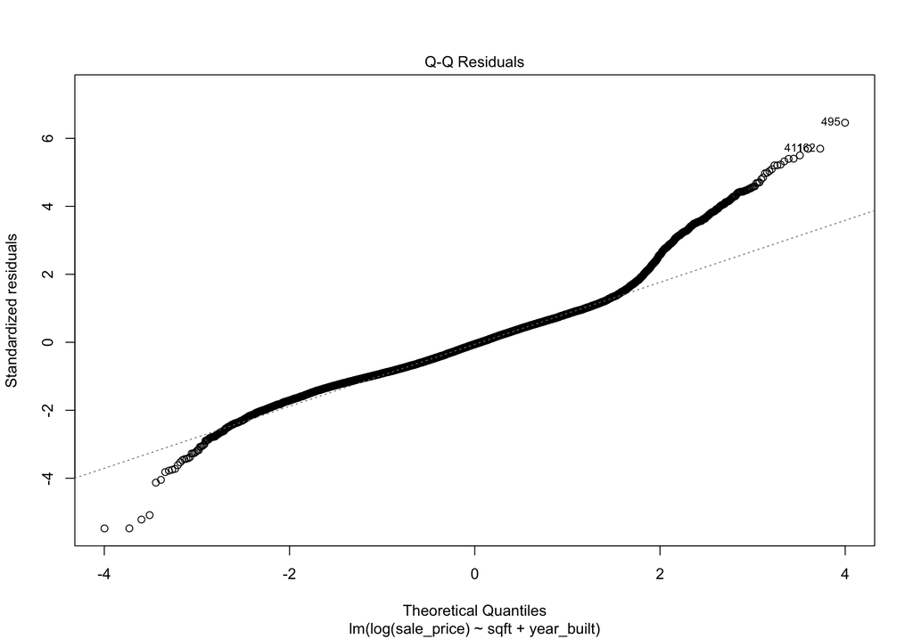

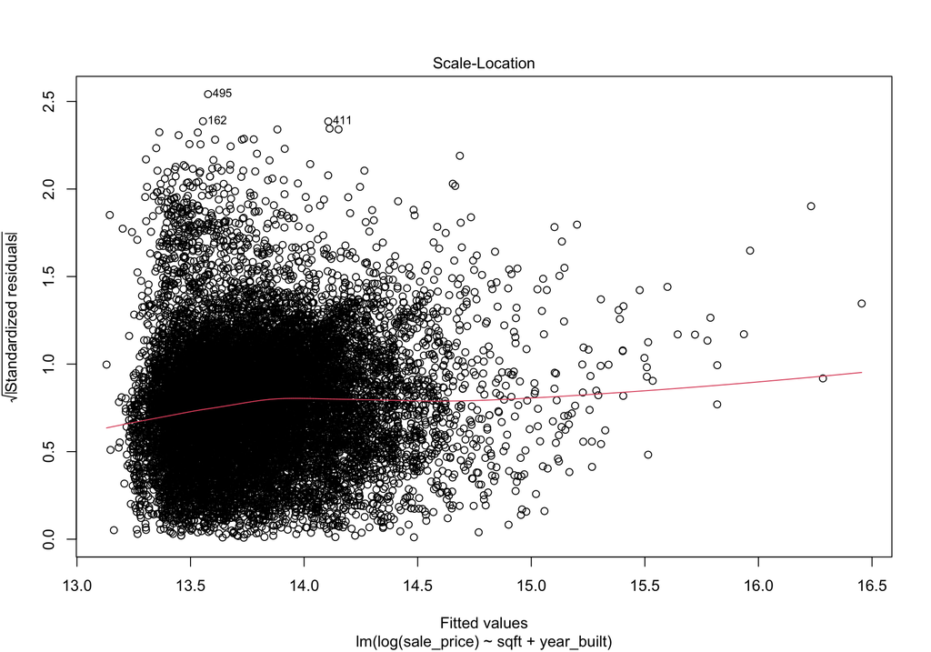

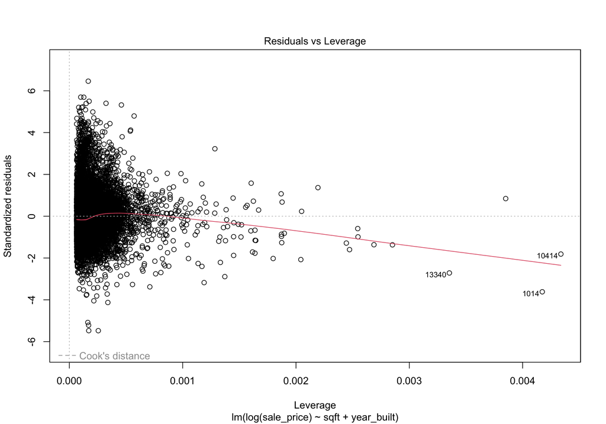

```r
log_simple_lm <- lm(data = sales, log(sale_price) ~ sqft + year_built)
plot(log_simple_lm)
```

```r
summary(log_simple_lm)
```

```
##
## Call:
## lm(formula = log(sale_price) ~ sqft + year_built, data = sales)
##
## Residuals:
##      Min       1Q   Median       3Q      Max
## -2.18762 -0.26969 -0.02224  0.22164  2.58006
##
## Coefficients:
##               Estimate Std. Error t value Pr(>|t|)
## (Intercept)  1.774e+01  1.997e-01   88.80   <2e-16 ***
## sqft         3.717e-04  3.651e-06  101.80   <2e-16 ***
## year_built  -2.395e-03  1.022e-04  -23.44   <2e-16 ***
## ---
## Signif. codes:  0 '***' 0.001 '**' 0.01 '*' 0.05 '.' 0.1 ' ' 1
##
## Residual standard error: 0.3995 on 15651 degrees of freedom
## Multiple R-squared:  0.3995, Adjusted R-squared:  0.3995
## F-statistic:  5207 on 2 and 15651 DF,  p-value: < 2.2e-16
```

You may notice that the $\beta$ in log-transformed model is quite small. Because of the transformation, our interpretation of $\beta$ could be different! Holding other variables constant, we change $X_1$ for one unit, we can write as:

$$\begin{aligned}
\log(Y_{changed}) & = \beta_0 + \beta_1 (X_1 + 1) + \beta_2 X_2 +
\varepsilon \\
& = \beta_0 + \beta_1 X_1 + \beta_2 X_2 +
\varepsilon + \beta_1 \\
& = \log(Y_{original}) + \beta_1\\
\beta_1 & = \log(Y_{changed}) - \log(Y_{original}) \\
& = \log(\frac{Y_{changed}}{Y_{original}}) \\
\exp(\beta_1) & = \frac{Y_{changed}}{Y_{original}}
\end{aligned}$$

We use `coef()` to get accurate $\beta$:

```r
coef(log_simple_lm)
```

```
##   (Intercept)          sqft    year_built
## 17.7377723721  0.0003717023 -0.0023949085
```

```r
exp(0.0003717023)
```

```
## [1] 1.000372
```

Note: if we want to know expected percentage change in price for 100 sqft, it should be $1.000372^{100}$ (+3.79%) instead of $0.000372 \times 100$ (+3.72%).

### Interactions and Non-linear Variables

An interaction means that the **effect** of one variable depends on the level of another variable. For example, we may think of the effect of house size on price changes depending on the house’s condition. We can add interaction terms by using `*`. Note: R will add `condition` itself as an explanatory variable in the following model:

```r
log_no_interaction_lm <- lm(data = sales, log(sale_price) ~ year_built + sqft + condition)
log_interaction_lm <- lm(data = sales, log(sale_price) ~ year_built + sqft + sqft * condition)
```

You could also have variables in you specification that are squared, cubed etc. such as:

```
model7 <- lm(sale_price ~  sqft + I(sqft^2) + cos(sqft), data = sales)
```

The `I()` is a base R command that forces R to evaluate anything inside the `I()` before anything else. Sometimes it is needed when conducting regressions.

### Compare Models

When compare with several models, we can use `modelsummary` package to display and compare regression results in one formatted table. It helps us quickly see how coefficients, significance levels, and model fit change.

```r
modelsummary(
  list(
    "Without Interaction Model" = log_no_interaction_lm,
    "Interaction Model" = log_interaction_lm
  ),
  stars = TRUE,
  fmt = 5,
  title = 'Comparsion Table between Models with/without Interaction',
  output = "html")
```

Comparsion Table between Models with/without Interaction

|  | Without Interaction Model | Interaction Model |
| --- | --- | --- |
| (Intercept) | 17.71652*** | 17.81729*** |
|  | (0.22059) | (0.22081) |
| year_built | −0.00239*** | −0.00232*** |
|  | (0.00011) | (0.00011) |
| sqft | 0.00037*** | 0.00026*** |
|  | (0.00000) | (0.00002) |
| condition | 0.00104 | −0.06512*** |
|  | (0.00458) | (0.01093) |
| sqft × condition |  | 0.00003*** |
|  |  | (0.00000) |
| Num.Obs. | 15654 | 15654 |
| R2 | 0.400 | 0.401 |
| R2 Adj. | 0.399 | 0.401 |
| AIC | 447439.8 | 447397.5 |
| BIC | 447478.1 | 447443.4 |
| Log.Lik. | −7846.290 | −7824.117 |
| F | 3471.285 | 2621.781 |
| RMSE | 0.40 | 0.40 |

+ p < 0.1, * p < 0.05, ** p < 0.01, *** p < 0.001

In an interaction model, the $\beta$ of individual variables (those also appearing in the interaction term) represent their effects only when the other interacting variable equals zero. So, it is a **baseline effect** and does not have much direct meanings. We must always interpret them together with the interaction term. In our interaction model:

- 0.00026: effect of sqft when condition = 0 (condition cannot be 0 in the data)
- -0.06512: effect of condition when sqft = 0 (square footage of house is not likely to be 0)

We see a significant positive interaction: the positive effect of square footage on price is stronger for houses in better condition. In other words, larger houses benefit more from good condition than smaller ones.

#### Performance Metrics

**R-squared and Adjusted R-squared [larger - better]**: Mentioned in the lecture, R-squared shows how much of the variation in the response variable is explained by the model. Adjusted R-squared corrects for the number of predictors, so it is better for comparing models with different numbers of variables.

**Root Mean Squared Error (RMSE) [smaller - better]**: Root of MSE, measures the average distance between the observed and predicted values. Smaller RMSE means better model fit.

**Akaike’s Information Criterion (AIC) [smaller - better]**: AIC is good for unknown data generating process(The AIC tries to select the model that most adequately describes an unknown, high dimensional reality. Akaike’s Information Criteria is good for making asymptotically equivalent to cross-validation. You can check AIC using `AIC(model)`.

**Bayesian Information Criterion (BIC) [smaller - better]**: BIC tries to find the TRUE model among the set of candidates. A lot of times, BIC and AIC will agrees on each other, but BIC penalize models that have a lot of parameters. Danger of underfit. Bayesian Information Criteria is good for consistent estimation. You can check BIC using `BIC(model)`.

### Prediction

We can use `predict` function to generate predicted values from a regression model.

```r
# we add a new column in sales dataframe
sales$predicted <- predict(log_interaction_lm, data = sales)
# check the prediction
sales$predicted[1]
```

```
##        1
## 13.56881
```

Check the prediction, we find the value is extremely small (13.57 << real sale price). We used log transformation to response variable! We need to transform the predicted values back by taking the exponential (exp) of each prediction to return them to the original sale price scale.

```r
sales$predicted_exp <- exp(sales$predicted)
sales$predicted_exp[1]
```

```
##        1
## 781375.6
```

### 📚 TODO: Explain the Results of Logistic Regression

**10 points**

**You may discuss in small group, but you must prepare the submission by yourself. Generative AI is NOT allowed for write-up questions. You ask conceptual questions but you need to cite properly. [How to cite?](https://www.yuehaoyu.com/data-analytics-visualization/syllabus/#use-of-ai)**

**Your submission should be HTML or PDF. Handwritten PDFs are acceptable as long as they are scanned and easy to read. Part B will not require any coding as well.**

In this section, we will read a recent research paper published by Runstad Department faculty Rebecca J. Walter, Arthur Acolin, Ruoniu (Vince) Wang, Gregg Colburn, along with people from other institutions: [**Exploring the association between household compositional change and mobility of subsidized householders in the United States**](https://doi.org/10.1080/07352166.2024.2371380). You are able to find the PDF version within the lab folder.

This study examines the relationship between household compositional change (such as a partner, child, or adult entering or leaving the household) and residential mobility of subsidized householders in the US. They use the Annual Longitudinal Files 2005–2018 from U.S. Department of Housing and Urban Development, which is restricted-use data required researchers to apply to access. [Northwest Federal Statistical Research Data Center](https://csde.washington.edu/services/northwest-federal-statistical-research-data-center/) is the center within UW partnered with U.S. Census Bureau to provide such data access.

Please skim the paper first and use the following to guide your further reading, especially about the **Data and methods** and **Results** parts.

#### Settings

1. [1 pt] What is the unit of analysis of this study? What is the sample size $N$? Is this study cross-sectional or longitudinal (lecture 2 data)?

   The unit of analysis in this study is a household-year observation, meaning each subsidized household is observed once per year. The sample contains about 15.8 million household-year observations (2005–2018). Because the same households are followed over multiple years, this is a longitudinal dataset rather than a cross-sectional one.
2. [0.5 pt] Why do you think U.S. Census Bureau requires us apply for the data usage instead of providing public access like American Community Survey (ACS) data?

   The U.S. Census Bureau restricts access because HUD’s Annual Longitudinal Files include sensitive, individual-level information. Variables such as household composition, subsidy status, income, and geographic identifiers could be used to re-identify households. Therefore, researchers must apply through the Federal Statistical Research Data Center (FSRDC) system rather than using the data publicly like ACS.
3. [0.5 pt] In a research paper, we tend to include two parts of explanatory variables: (1) the **key explanatory variables (or variables of interest)**, which directly address the research question; and (2) the **control variables**, which account for other factors that might also influence the response variable. In this paper, what are the key explanatory variables and response variable?

   The key explanatory variables are indicators of household compositional change, such as a partner, adult, or child entering or exiting the household. The response variable is whether the household moved during that year (binary: 1 = moved, 0 = not moved).
4. [1 pt] What is the purpose of including local market characteristics as part of $X$? Even though we do not have access to the data, which variables could be multicollinear with local market characteristics?

   Local market characteristics are included so that the model accounts for structural differences across housing markets that influence mobility. Without these controls, the model may incorrectly attribute market-level factors to household-level compositional changes. Variables likely to be collinear with local market characteristics include rent levels, vacancy rates, poverty rates, unemployment rates, and neighborhood income, since these economic conditions tend to move together.
5. [0.5 pt] Can we use normal linear regression for this study?

   A normal linear regression is not appropriate because the outcome is binary. A linear probability model would violate assumptions of homoscedasticity and could generate predicted values outside the 0–1 range. Logistic regression is the correct specification.
6. [0.5 pt] The follow picture shows model specification in page 8 of this paper. Do you find any problem with this equation and explanation, especially for the explanatory variable part?

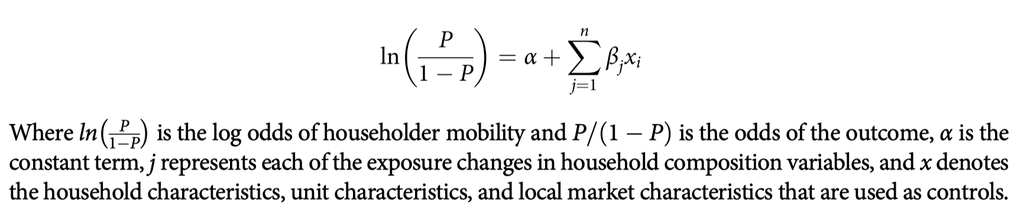

Page 8 - Model Specification

#### Model Configurations and Results

This study use logistic regression, which is similar to linear regression but for binary response variable (1/0). We change $Y$ with $\log(P/(1-P))$, where $P$ is the probability of $Y=1$. [This post from IBM would be helpful to understand logistic regression.](https://www.ibm.com/think/topics/logistic-regression) Think about this model:

$$\log(\frac{P}{1-P}) = \beta_0 + \beta_1 X_1 + \beta_2 X_2$$

1. [1 pt] How should we interpret $\beta_1$?

   In a logistic regression, $\beta_1$ represents the change in the log-odds of moving associated with a one-unit increase in X₁, holding other variables constant. Equivalently, exp($\beta_1$) gives the multiplicative change in the odds.
2. [0.5 pt] In the result tables of this paper, they use **Odds Ratio** rather than the coefficient of $X$. How could you calculate the coefficient $\beta$ for Household Member Enters or Exits (with odd ratio of 1.671)? The table below shows part of the results.

   The odds ratio is 1.671. Converting it to the coefficient:

   $\beta$ = log(1.671) ≈ 0.51.
3. [0.5 pt] How much more likely are households with a compositional change (a member entering or exiting) to move, compared to those without, controlling for other factors?

   An odds ratio of 1.671 means that households experiencing a compositional change are about 67% more likely to move than households without such changes, controlling for other factors.
4. [1 pt] What are the null and alternative hypotheses being tested by the t-value (398.7) for “Household Member Enters or Exits” in Model 1? What is the meaning of ‘***’?

   The null hypothesis is that $\beta$ = 0 (compositional change has no association with moving).

   The alternative hypothesis is $\beta$ ≠ 0.

   The “***” symbol indicates statistical significance at p < 0.001, meaning very strong evidence against the null hypothesis.
5. [1 pt] They conducted at least three logistic regression models. Why did they do that?

   The authors estimate multiple models to check robustness. Each model adds more controls (e.g., demographic characteristics, economic variables, market characteristics). If the coefficient for compositional change remains stable across models, the result is less likely to be driven by omitted-variable bias.
6. [1 pt] The authors only use tables to present results. What is one way to visualize the adds ratio from this logistic model to show uncertainty of the results? You can use a plot example to illustrate.

   One way to visualize the odds ratios is a coefficient plot (forest plot). Each point represents an odds ratio, with horizontal lines showing 95% confidence intervals and a vertical reference line at OR = 1. This makes it easier to observe uncertainty and compare effects across variables.
7. [1 pt] The title of this paper uses *association* rather than *effect*, *impact*, or *influence*. Authors are also very cautious term usages in main text. What is the reason?

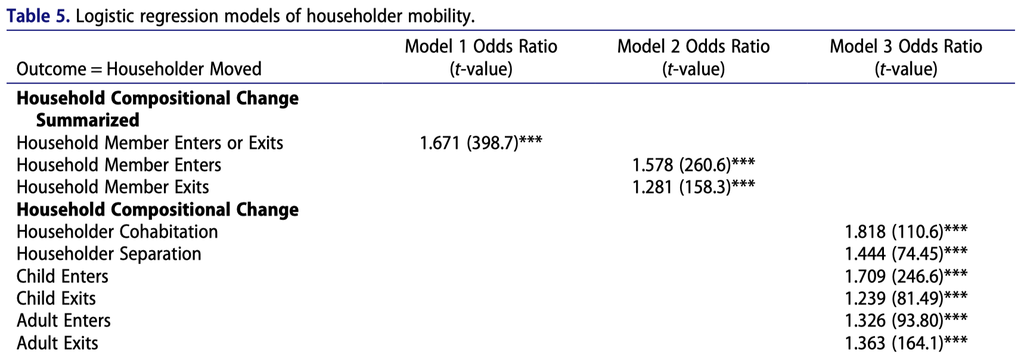

Table 5 - Logistic Regression Results

The term “association” is used because the study is observational. Without a causal identification strategy, the authors cannot claim that compositional change causes mobility. They can only document correlations, not causal effects.

## Lab 07-B: Regression in Machine Learning

We will use [`tidymodels`](https://www.tidymodels.org), which is a R package for modeling and machine learning in R using tidyverse principles. It provides us a framework. It is helpful to know that machine learning and deep learning are normally run with Python. For the consistence of this class, we will continue use R. But it is not difficult to transfer to Python! Some resources:

- [An Introduction to Python for R Users](https://rebeccabarter.com/blog/2023-09-11-from_r_to_python)
- [Conversion R and Python](https://www.mit.edu/~amidi/teaching/data-science-tools/conversion-guide/r-python-data-manipulation/)

```r
library(tidymodels)
```

### Data Preparation

There are too many variables can be added to the model. Some are not suitable for a prediction task, such as longitude and latitude. We start from remove some data columns and merge some of them. After that, do some cleaning based on inspection.

In a more rigorous machine learning process, we may conduct feature engineering and selection before training. For example, we could use [Principal Component Analysis (PCA)](https://en.wikipedia.org/wiki/Principal_component_analysis) to reduce dimension or select most important features based on correlation results. A more comprehensive book on this: [Feature Engineering and Selection: A Practical Approach for Predictive Models](http://www.feat.engineering).

```r
sales_pred <- sales %>%
  mutate(view_mountains = view_rainier + view_olympics + view_cascades + view_territorial,
         view_water = view_sound + view_lakewash + view_lakesamm + view_otherwater)
# select some features (subjective here)
sales_pred <- sales_pred %>%
  dplyr::select(sale_price, year_built, sqft_lot, sqft, beds, view_skyline, view_mountains, view_water)
```

Before train the model, we need to split the dataset into a training set and a testing set. The training data will be used to train the models, while the testing data will be reserved to evaluate how well the model generalizes to unseen observations.

```r
set.seed(123)
split <- initial_split(sales_pred, prop = 0.8) # 80% training data
train_data <- training(split)
test_data  <- testing(split)
```

We are going to build a recipe for data preprocessing. A recipe is the steps to do data preparation under `tidymodels` framework. For Lasso and ridge, we need to normalize features.

```r
rec <- recipe(sale_price ~ ., data = train_data) %>% # model and dataset
  step_poly(year_built, degree = 5) %>% # add polynomial expansion to x, x^2, x^3, x^4, x^5
  step_poly(sqft, degree = 5) %>%
  step_poly(sqft_lot, degree = 5) %>%
  step_poly(beds, degree = 5) %>%
  step_zv(all_numeric()) %>% # remove variables that contain only a single value
  step_normalize(all_predictors()) # normalize (center and scale) the numeric variables
```

Please note that The object `rec` is a recipe that has **not been trained** on data yet (for example, does not normalize).

### Model Specification

We start from specify the lasso regression. In `tidymodels`, the model type (`linear_reg`) and the computational engine (`glmnet`) are separated.

```r
lasso_spec <- linear_reg(
  penalty = tune(), # penalty hyperparameter: tuneable and selected by cross-validation
  mixture = 1
  # mixture = 1 is lasso and mixture = 0 is ridge
  # mixture in (0,1) is elastic net (combination of lasso and ridge)
) %>%
  set_engine("glmnet") # specify which package or system will be used to fit the model
  # `glmnet` is the engine that implements penalized linear models.
```

A workflow is a container that bundles together a recipe (data preprocessing steps) and a model specification.

```r
# use `workflow()` to put receipt and models together. We have not train yet!
lasso_workflow <- workflow() %>%
  add_recipe(rec) %>%
  add_model(lasso_spec)
```

### Tuning Grid for Penalty

We can define the search space for $\lambda$. `penalty(range = c(a, b))` specifies the log10 scale from $10^a$ - $10^b$.

```r
lambda_grid <- grid_regular(
  penalty(range = c(2, 5)), # 100 - 10000; determined by yourself after attempts
  levels = 50 # try 50 values between the previous range
)
```

### Cross-validation Setup

We make 5 folds to separate the `train_data` into five equally sized subsets for cross-validation.

```r
folds <- vfold_cv(train_data, v = 5)
```

### Model Training via Grid Search

```r
tune_results <- tune_grid(
  lasso_workflow,
  resamples = folds,
  grid = lambda_grid,
  metrics = metric_set(rmse, rsq) # we evaluate two metrics: RMSE (error) and R² (fit)
)
```

### Cross-validation Results

We show the model performance changes as $\lambda$ increases via a curve.

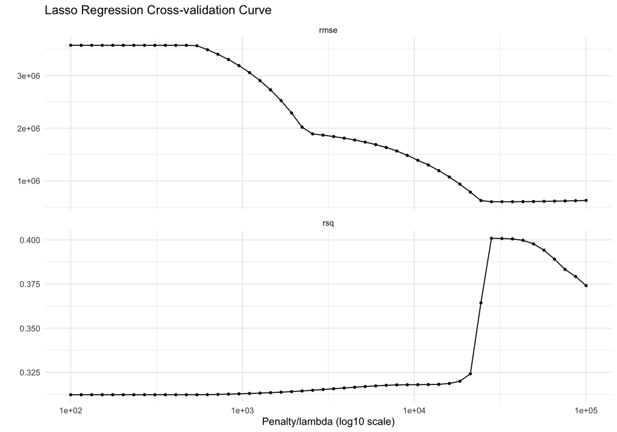

```r
autoplot(tune_results)+
  theme_minimal(base_size = 12) +
  labs(title = "Lasso Regression Cross-validation Curve",
       x = "Penalty/lambda (log10 scale)")
```

### Fit the Final Model using the Best $\lambda$

```r
best_lasso <- select_best(tune_results, metric = "rmse")

# another workflow
final_lasso <- workflow() %>%
  add_model(finalize_model(lasso_spec, best_lasso)) %>% # finalize_model() inserts the chosen lambda into the model specification
  add_recipe(rec) %>% # the same recipe
  fit(train_data) # train the final Lasso model using the full training set
```

We can check the final coefficients using `tidy(workflow)`. variables with estimate = 0 have been removed by lasso regression.

```r
tidy(final_lasso) %>% filter(estimate != 0)
```

```
## # A tibble: 8 × 3
##   term              estimate penalty
##   <chr>                <dbl>   <dbl>
## 1 (Intercept)       1129450.  28118.
## 2 view_skyline        32961.  28118.
## 3 view_water         152808.  28118.
## 4 year_built_poly_1  -56966.  28118.
## 5 year_built_poly_3    6192.  28118.
## 6 sqft_poly_1        389353.  28118.
## 7 sqft_poly_2         99505.  28118.
## 8 sqft_poly_5          1415.  28118.
```

#### Testing

We evaluate the performance of the final Lasso model on the held-out test set. The `predict()` function generates predicted sale prices for the test data, and `metrics()` computes evaluation measures such as RMSE and R².

```r
pred_lasso <- predict(final_lasso, test_data) %>%
  bind_cols(test_data)
metrics(pred_lasso, truth = sale_price, estimate = .pred)
```

```
## # A tibble: 3 × 3
##   .metric .estimator  .estimate
##   <chr>   <chr>           <dbl>
## 1 rmse    standard   663413.
## 2 rsq     standard        0.387
## 3 mae     standard   357505.
```

### 📚 TODO: Review the Code for Regression

**2 points**

Carefully review and run all code chunks. You are encouraged to modify the model and explore ridge regression. Reply “yes” once you have reviewed them.

yes

### 📚 TODO: Machine Learning to Predict the Rental Value

**4 points**

In this section, we will read a recent research paper that applies several machine learning regression techniques—including Lasso, Ridge, and tree-based models—to predict housing rental values in three African countries. The paper, [Predicting the rental value of houses using hedonic and machine learning regression models](https://doi.org/10.1371/journal.pone.0244953) examines how different modeling approaches perform when estimating rental values based on a wide range of housing characteristics, infrastructure indicators, and household attributes. You can find the PDF version of the article in the lab folder. Please skim the paper first and response to following questions. You can skip the parts beyond regression.

1. [1 pt] Why do we need regularization in Lasso and Ridge regression? What effect does regularization have on variance and bias, respectively?

   Regularization is needed because models with many predictors can easily overfit the training data. Lasso and Ridge add penalties to the size of coefficients, which shrink the model toward simpler structures. Regularization reduces variance but increases bias, creating a bias–variance tradeoff that usually improves out-of-sample performance.
2. [1 pt] In the model, the variable “roof” equals 1 if the house has a mud roof and 0 otherwise. If the Lasso regression sets the coefficient of this variable to zero in 2010, can we conclude that roof type is not associated with rental value? Why or why not?

   If Lasso assigns a coefficient of zero to the “roof” variable in 2010, we cannot conclude that roof type has no association with rental value. A zero coefficient means that, given the other predictors in the model, roof type does not improve predictive accuracy. It does not imply the true relationship is zero. The result may be driven by multicollinearity or by Lasso’s variable selection behavior.
3. [1 pt] Why do the authors use cross-validation in their analysis? And how cross-validation is used to choose the regularization parameter ($\lambda$) in Lasso and Ridge regression?

   The authors use cross-validation to estimate how well different models generalize to new data. For Lasso and Ridge, cross-validation is used to choose the penalty parameter $\lambda$. The algorithm fits models across a range of $\lambda$ values, evaluates prediction errors in the validation folds, and selects the $\lambda$ that minimizes out-of-sample error.
4. [1 pt] In the prediction performance table, OLS performs best in the in-sample evaluation, while Lasso and Ridge outperform OLS in the out-of-sample evaluation. Could you guess the reason for this pattern?

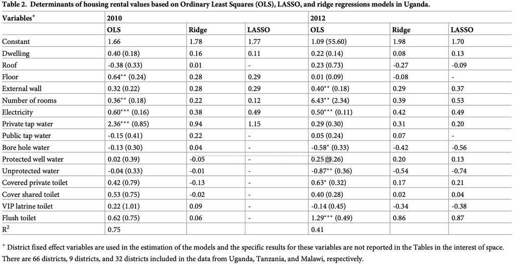

Determinants (~Coefficients) of Housing Rental Values

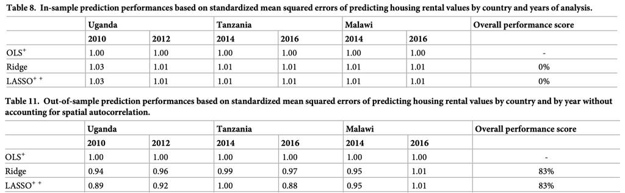

In-sample and Out-of-sample Prediction Performances

OLS performs best in-sample because it fully fits the training data and has no penalty term. However, this also means it is more likely to overfit and perform worse on new data. Lasso and Ridge shrink coefficients, which reduces overfitting and improves out-of-sample predictions. Therefore, OLS tends to have the lowest training error but worse test error, while regularized models perform better when predicting unseen data.

## Acknowledgement

The materials are developed by Haoyu Yue based materials from [Dr. Feiyang Sun at UC San Diego](https://fsun.ucsd.edu), Siman Ning and Christian Phillips at University of Washington, [Dr. Charles Lanfear at University of Cambridge](https://clanfear.github.io).